# task4 - Цзян Чжэнхуа

2024-03-21

## task4(Вариант13)

Сначала считайте данные из файла csv и преобразуйте их в форму временного ряда.

```r
setwd("C:\\Users\\lenovo\\Desktop\\时间序列分析\\tsa4")
dat <- read.csv("TrainingData.csv")
dat <- dat[complete.cases(dat), ]

# par(mfrow = c(1, 1), mar = c(5, 4, 4, 2) + 0.1)
x <- ts(dat$Значение,start = c(2017,1),frequency = 12)
x
```

```
##       Jan  Feb  Mar  Apr  May  Jun  Jul  Aug  Sep  Oct  Nov  Dec
## 2017  2.5  0.8  0.9  1.2  1.5  1.5  1.4  1.8  1.6  1.9  1.7  1.8
## 2018  1.5  2.9  2.1  1.8  1.8  1.9  2.1  2.3  2.5  2.5  2.2  1.9
## 2019  1.7  1.5  2.3  2.5  2.7  2.7  2.8  2.8  3.0  3.8  4.5  4.5
## 2020  5.4  5.2  4.3  3.3  2.4  2.5  2.7  2.4  1.7  0.5 -0.5  0.2
## 2021 -0.3 -0.2  0.4  0.9  1.3  1.1  1.0  0.8  0.7  1.5  2.3  1.5
## 2022  0.9  0.9  1.5  2.1  2.1  2.5  2.7  2.5  2.8  2.1  1.6  1.8
## 2023  2.1  1.0  0.7  0.1  0.2  0.0 -0.3  0.1  0.0 -0.2 -0.5 -0.3
## 2024 -0.8  0.7
```

Визуализация временных рядов

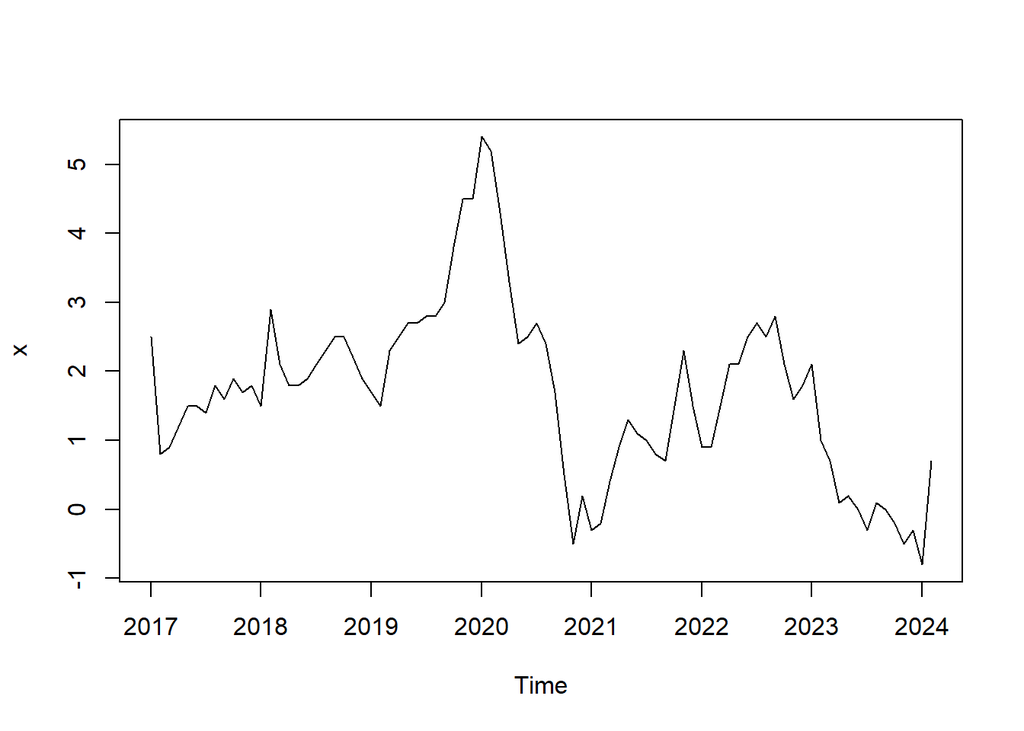

```r
plot(x)
```

### Проверить данные на стационарность.

```r
library(aTSA)
adf.test(x)
```

```
## Augmented Dickey-Fuller Test
## alternative: stationary
##
## Type 1: no drift no trend
##      lag   ADF p.value
## [1,]   0 -1.46   0.153
## [2,]   1 -1.24   0.232
## [3,]   2 -1.27   0.223
## [4,]   3 -1.21   0.245
## Type 2: with drift no trend
##      lag   ADF p.value
## [1,]   0 -1.99   0.334
## [2,]   1 -2.26   0.227
## [3,]   2 -2.27   0.223
## [4,]   3 -2.05   0.310
## Type 3: with drift and trend
##      lag   ADF p.value
## [1,]   0 -2.18   0.493
## [2,]   1 -2.73   0.273
## [3,]   2 -2.71   0.281
## [4,]   3 -2.45   0.387
## ----
## Note: in fact, p.value = 0.01 means p.value <= 0.01
```

```r
# white noise test
for(k in 1:2) print(Box.test(x,lag = 6*k))
```

```
##
##  Box-Pierce test
##
## data:  x
## X-squared = 218.16, df = 6, p-value < 2.2e-16
##
##
##  Box-Pierce test
##
## data:  x
## X-squared = 234.31, df = 12, p-value < 2.2e-16
```

### К полученным данным идентифицировать и оценить две различных, но обоснованно возможных ARMA модели.

Постройте графики автокорреляции и частичной автокорреляции последовательности

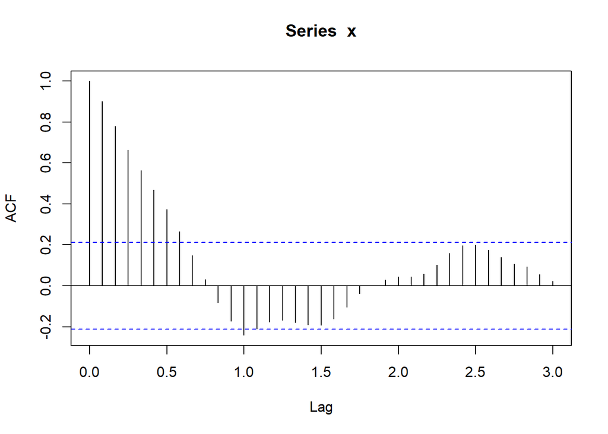

```r
acf(x,lag=36)
```

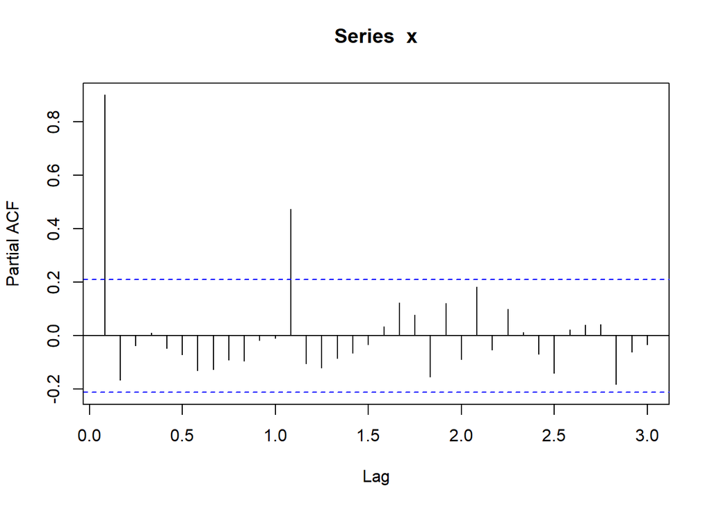

```r
pacf(x,lag=36)
```

Как видно из графика временного ряда, в нем присутствует сезонный эффект с периодом 12.Ниже приводится предварительное определение порядка модели на основе графиков ACF и PACF:

#### Несезонный компонент

Для определения краткосрочной корреляционной модели для несезонной компоненты рассматриваются коэффициенты автокорреляции и коэффициенты частичной автокорреляции, характеризующие ряд до 12-го порядка.Как видно из рисунка, коэффициенты автокорреляции вплоть до 12-го порядка демонстрируют трейлинг. В то время как частичные коэффициенты автокорреляции демонстрируют усечение 1-го порядка, за исключением частичных коэффициентов автокорреляции 1-го порядка, которые находятся в диапазоне 2-кратного стандартного отклонения.

Поэтому в качестве модели несезонной компоненты была использована модель ARMA(1,0).

#### Сезонный компонент

Для характеристик сезонной автокорреляции исследуются коэффициенты автокорреляции и частичные коэффициенты автокорреляции по длине цикла для задержки 12-го порядка, 24-го порядка и т.д.

Поэтому сезонность можно охарактеризовать с помощью модели ARMA (0,1) или ARMA (1,1).

#### целостная модель

На основании полученных результатов были определены две возможные модели: SARMA(1,0,0)(0,0,1)(12) и SARMA(1,0,0)(1,0,1)(12).

### Оценка модели и выбрать из них наиболее адекватную

```r
library("lmtest")
x.fit <- arima(x,order = c(1,0,0),seasonal = list(order = c(0,0,1),period=12),method = "ML")
x.fit
```

```
##
## Call:
## arima(x = x, order = c(1, 0, 0), seasonal = list(order = c(0, 0, 1), period = 12),
##     method = "ML")
##
## Coefficients:
##          ar1     sma1  intercept
##       0.9683  -1.0000     1.7281
## s.e.  0.0388   0.1784     0.2471
##
## sigma^2 estimated as 0.1279:  log likelihood = -46.63,  aic = 101.26
```

```r
coeftest(x.fit)
```

```
##
## z test of coefficients:
##
##           Estimate Std. Error z value  Pr(>|z|)
## ar1        0.96833    0.03875 24.9889 < 2.2e-16 ***
## sma1      -1.00000    0.17843 -5.6046 2.088e-08 ***
## intercept  1.72813    0.24714  6.9926 2.698e-12 ***
## ---
## Signif. codes:  0 '***' 0.001 '**' 0.01 '*' 0.05 '.' 0.1 ' ' 1
```

AIC_1 = 101.26

```r
library("lmtest")
x.fit1 <- arima(x,order = c(1,0,0),seasonal = list(order = c(1,0,1),period=12),method = "ML")
x.fit1
```

```
##
## Call:
## arima(x = x, order = c(1, 0, 0), seasonal = list(order = c(1, 0, 1), period = 12),
##     method = "ML")
##
## Coefficients:
##          ar1     sar1     sma1  intercept
##       0.9780  -0.1513  -0.9998     1.7200
## s.e.  0.0355   0.1180   0.2865     0.2508
##
## sigma^2 estimated as 0.1214:  log likelihood = -45.86,  aic = 101.72
```

```r
coeftest(x.fit1)
```

```
##
## z test of coefficients:
##
##            Estimate Std. Error z value  Pr(>|z|)
## ar1        0.978017   0.035494 27.5545 < 2.2e-16 ***
## sar1      -0.151343   0.117999 -1.2826 0.1996406
## sma1      -0.999756   0.286489 -3.4897 0.0004836 ***
## intercept  1.719984   0.250752  6.8593  6.92e-12 ***
## ---
## Signif. codes:  0 '***' 0.001 '**' 0.01 '*' 0.05 '.' 0.1 ' ' 1
```

AIC_2 = 101.72

Согласно критерию AIC, модель SARMA(1,0,0)(0,0,1)(12) может быть признана более адекватной. Таким образом, итоговая модель имеет параметры p=1,q=0,S=12,P=0,Q=1,d=0.

где

p - порядок не сезонной авторегрессии

q - порядок не сезонного скользящего среднего

S - период сезонности

P - порядок сезонной авторегрессии

Q - порядок сезонного скользящего среднего

d - порядок разности: 0 -не было разностей, 1- были разности

### Провести анализ остатков от удаления модели:тип вероятностного распределения,автокоррелированность остатков.

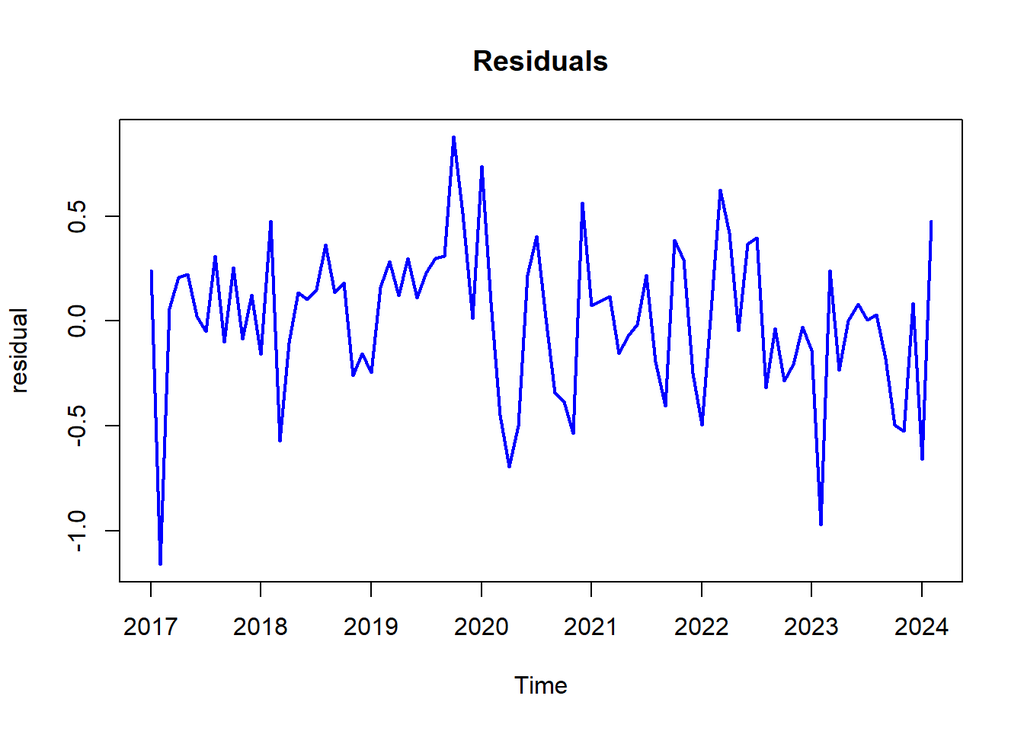

```r
residual <- x.fit$residuals
plot(residual ,type = "l", col = "blue",lwd = 2,main = "Residuals")
```

```r
Box.test(residual, lag = 16, type = "Ljung-Box", fitdf = 2)
```

```
##
##  Box-Ljung test
##
## data:  residual
## X-squared = 8.4322, df = 14, p-value = 0.8656
```

Согласно полученному p-значению, автокорреляция в остатках отсутствует.

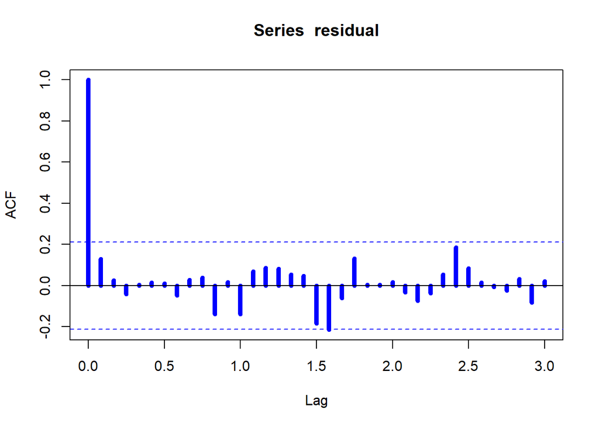

```r
acf(residual,lwd = 5,lag.max = 36, col = "blue")
```

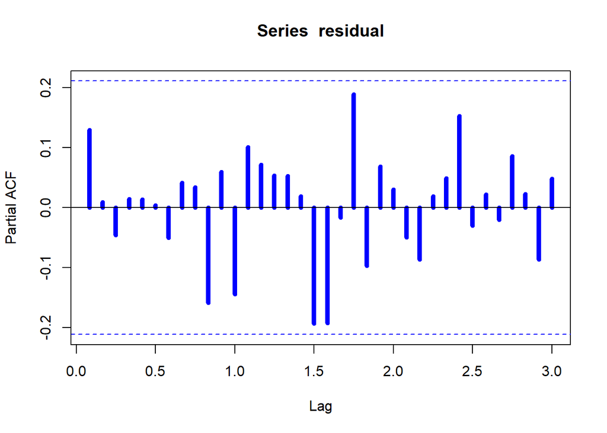

```r
pacf(residual,lwd = 5,lag.max = 36, col = "blue")
```

Как видно из графиков ACF и PACF, остатки не противоречат предположению о белом шуме.

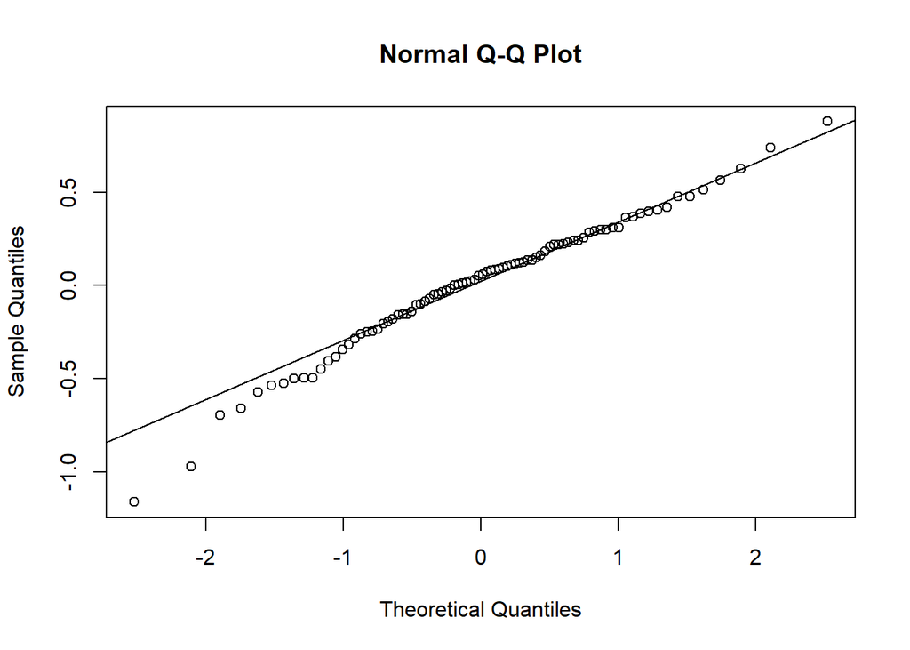

```r
qqnorm(residual)
qqline(residual)
```

```r
shapiro.test(residual)
```

```
##
##  Shapiro-Wilk normality test
##
## data:  residual
## W = 0.97895, p-value = 0.1734
```

Согласно графику qq и тесту Шапиро, остатки удовлетворяют нормальному распределению.

### Построить прогноз и доверительный интервал для прогноза уровня 0.95 на 12 интервалов времени вперед.

```r
library(forecast)
```

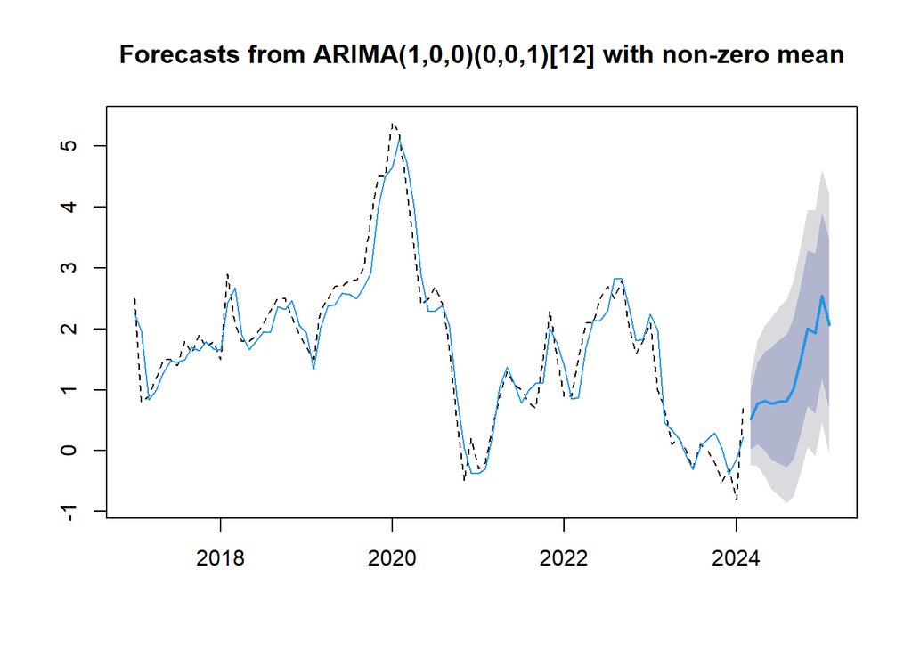

```r
x.fore <- forecast(x.fit,h=12)
plot(x.fore,lty = 2)
lines(fitted(x.fit),col=4)
```

### Построить прогноз по модели (сезонной, если она есть) Holta-Winters на 12 интервалов времени вперед.

Поскольку присутствуют сезонные эффекты, использовалась трехпараметрическая модель экспоненциального сглаживания Holt-Winters.

```r
# Holt-Winter three-parameter exponential smoothing method
x.fit2 <- HoltWinters(x)
x.fit2
```

```
## Holt-Winters exponential smoothing with trend and additive seasonal component.
##
## Call:
## HoltWinters(x = x)
##
## Smoothing parameters:
##  alpha: 0.8649404
##  beta : 0.001468717
##  gamma: 1
##
## Coefficients:
##            [,1]
## a    0.42273644
## b    0.04745348
## s1   0.32564029
## s2  -0.01202706
## s3  -0.22041051
## s4  -0.27004191
## s5  -0.21189678
## s6  -0.01631850
## s7  -0.06041940
## s8  -0.07464528
## s9  -0.13066620
## s10 -0.07946060
## s11 -0.29805010
## s12  0.27726356
```

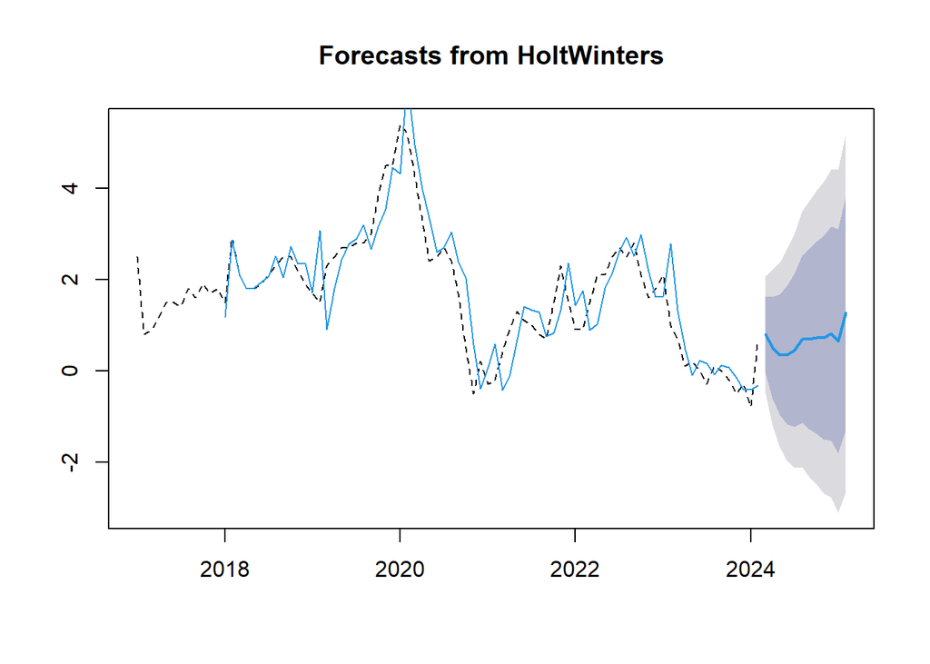

```r
x.fore_holtwinter <- forecast(x.fit2,h=12)
plot(x.fore_holtwinter,lty = 2)
lines(x.fore_holtwinter$fitted ,col=4)
```